# Risk Factor Analysis

## Outcome Variable

**Outcome Variable:** wast_rec90d

## Predictor Variables

**Intervention Variable:** mage

**Adjustment Set:**

- arm
- meducyrs
- feducyrs
- W_mhtcm
- W_mwtkg
- W_mbmi
- delta_meducyrs
- delta_feducyrs
- delta_W_mhtcm
- delta_W_mwtkg
- delta_W_mbmi

## Stratifying Variables

The analysis was stratified on these variable(s):

- agecat
- studyid
- country

## Data Summary

| agecat | studyid | country | mage | wast_rec90d | n_cell | n |
| --- | --- | --- | --- | --- | --- | --- |
| 0-24 months | ki0047075b-MAL-ED | BANGLADESH | [20-30) | 0 | 24 | 124 |
| 0-24 months | ki0047075b-MAL-ED | BANGLADESH | [20-30) | 1 | 46 | 124 |
| 0-24 months | ki0047075b-MAL-ED | BANGLADESH | <20 | 0 | 8 | 124 |
| 0-24 months | ki0047075b-MAL-ED | BANGLADESH | <20 | 1 | 18 | 124 |
| 0-24 months | ki0047075b-MAL-ED | BANGLADESH | >=30 | 0 | 12 | 124 |
| 0-24 months | ki0047075b-MAL-ED | BANGLADESH | >=30 | 1 | 16 | 124 |
| 0-24 months | ki0047075b-MAL-ED | BRAZIL | [20-30) | 0 | 3 | 24 |
| 0-24 months | ki0047075b-MAL-ED | BRAZIL | [20-30) | 1 | 11 | 24 |
| 0-24 months | ki0047075b-MAL-ED | BRAZIL | <20 | 0 | 0 | 24 |
| 0-24 months | ki0047075b-MAL-ED | BRAZIL | <20 | 1 | 4 | 24 |
| 0-24 months | ki0047075b-MAL-ED | BRAZIL | >=30 | 0 | 3 | 24 |
| 0-24 months | ki0047075b-MAL-ED | BRAZIL | >=30 | 1 | 3 | 24 |
| 0-24 months | ki0047075b-MAL-ED | INDIA | [20-30) | 0 | 59 | 180 |
| 0-24 months | ki0047075b-MAL-ED | INDIA | [20-30) | 1 | 87 | 180 |
| 0-24 months | ki0047075b-MAL-ED | INDIA | <20 | 0 | 11 | 180 |
| 0-24 months | ki0047075b-MAL-ED | INDIA | <20 | 1 | 17 | 180 |
| 0-24 months | ki0047075b-MAL-ED | INDIA | >=30 | 0 | 1 | 180 |
| 0-24 months | ki0047075b-MAL-ED | INDIA | >=30 | 1 | 5 | 180 |
| 0-24 months | ki0047075b-MAL-ED | NEPAL | [20-30) | 0 | 18 | 98 |
| 0-24 months | ki0047075b-MAL-ED | NEPAL | [20-30) | 1 | 63 | 98 |
| 0-24 months | ki0047075b-MAL-ED | NEPAL | <20 | 0 | 1 | 98 |
| 0-24 months | ki0047075b-MAL-ED | NEPAL | <20 | 1 | 2 | 98 |
| 0-24 months | ki0047075b-MAL-ED | NEPAL | >=30 | 0 | 1 | 98 |
| 0-24 months | ki0047075b-MAL-ED | NEPAL | >=30 | 1 | 13 | 98 |
| 0-24 months | ki0047075b-MAL-ED | PERU | [20-30) | 0 | 3 | 35 |
| 0-24 months | ki0047075b-MAL-ED | PERU | [20-30) | 1 | 15 | 35 |
| 0-24 months | ki0047075b-MAL-ED | PERU | <20 | 0 | 2 | 35 |
| 0-24 months | ki0047075b-MAL-ED | PERU | <20 | 1 | 9 | 35 |
| 0-24 months | ki0047075b-MAL-ED | PERU | >=30 | 0 | 1 | 35 |
| 0-24 months | ki0047075b-MAL-ED | PERU | >=30 | 1 | 5 | 35 |

[output cut: 450 more lines]

The following strata were considered:

- agecat: 0-24 months, studyid: ki0047075b-MAL-ED, country: BANGLADESH
- agecat: 0-24 months, studyid: ki0047075b-MAL-ED, country: BRAZIL
- agecat: 0-24 months, studyid: ki0047075b-MAL-ED, country: INDIA
- agecat: 0-24 months, studyid: ki0047075b-MAL-ED, country: NEPAL
- agecat: 0-24 months, studyid: ki0047075b-MAL-ED, country: PERU
- agecat: 0-24 months, studyid: ki0047075b-MAL-ED, country: SOUTH AFRICA
- agecat: 0-24 months, studyid: ki0047075b-MAL-ED, country: TANZANIA, UNITED REPUBLIC OF
- agecat: 0-24 months, studyid: ki1000108-CMC-V-BCS-2002, country: INDIA
- agecat: 0-24 months, studyid: ki1000108-IRC, country: INDIA
- agecat: 0-24 months, studyid: ki1000109-EE, country: PAKISTAN
- agecat: 0-24 months, studyid: ki1000304b-SAS-CompFeed, country: INDIA
- agecat: 0-24 months, studyid: ki1000304b-SAS-FoodSuppl, country: INDIA
- agecat: 0-24 months, studyid: ki1017093-NIH-Birth, country: BANGLADESH
- agecat: 0-24 months, studyid: ki1017093b-PROVIDE, country: BANGLADESH
- agecat: 0-24 months, studyid: ki1017093c-NIH-Crypto, country: BANGLADESH
- agecat: 0-24 months, studyid: ki1066203-TanzaniaChild2, country: TANZANIA, UNITED REPUBLIC OF
- agecat: 0-24 months, studyid: ki1101329-Keneba, country: GAMBIA
- agecat: 0-24 months, studyid: ki1112895-Guatemala BSC, country: GUATEMALA
- agecat: 0-24 months, studyid: ki1112895-iLiNS-Zinc, country: BURKINA FASO
- agecat: 0-24 months, studyid: ki1113344-GMS-Nepal, country: NEPAL
- agecat: 0-24 months, studyid: ki1119695-PROBIT, country: BELARUS
- agecat: 0-24 months, studyid: ki1126311-ZVITAMBO, country: ZIMBABWE
- agecat: 0-24 months, studyid: ki1135781-COHORTS, country: GUATEMALA
- agecat: 0-24 months, studyid: ki1135781-COHORTS, country: INDIA
- agecat: 0-24 months, studyid: ki1135781-COHORTS, country: PHILIPPINES
- agecat: 0-24 months, studyid: ki1148112-LCNI-5, country: MALAWI
- agecat: 0-24 months, studyid: kiGH5241-JiVitA-3, country: BANGLADESH
- agecat: 0-6 months, studyid: ki0047075b-MAL-ED, country: BANGLADESH
- agecat: 0-6 months, studyid: ki0047075b-MAL-ED, country: BRAZIL
- agecat: 0-6 months, studyid: ki0047075b-MAL-ED, country: INDIA
- agecat: 0-6 months, studyid: ki0047075b-MAL-ED, country: NEPAL
- agecat: 0-6 months, studyid: ki0047075b-MAL-ED, country: PERU
- agecat: 0-6 months, studyid: ki0047075b-MAL-ED, country: SOUTH AFRICA
- agecat: 0-6 months, studyid: ki0047075b-MAL-ED, country: TANZANIA, UNITED REPUBLIC OF
- agecat: 0-6 months, studyid: ki1000108-CMC-V-BCS-2002, country: INDIA
- agecat: 0-6 months, studyid: ki1000108-IRC, country: INDIA
- agecat: 0-6 months, studyid: ki1000109-EE, country: PAKISTAN
- agecat: 0-6 months, studyid: ki1000304b-SAS-CompFeed, country: INDIA
- agecat: 0-6 months, studyid: ki1000304b-SAS-FoodSuppl, country: INDIA
- agecat: 0-6 months, studyid: ki1017093-NIH-Birth, country: BANGLADESH
- agecat: 0-6 months, studyid: ki1017093b-PROVIDE, country: BANGLADESH
- agecat: 0-6 months, studyid: ki1017093c-NIH-Crypto, country: BANGLADESH
- agecat: 0-6 months, studyid: ki1066203-TanzaniaChild2, country: TANZANIA, UNITED REPUBLIC OF
- agecat: 0-6 months, studyid: ki1101329-Keneba, country: GAMBIA
- agecat: 0-6 months, studyid: ki1112895-Guatemala BSC, country: GUATEMALA
- agecat: 0-6 months, studyid: ki1113344-GMS-Nepal, country: NEPAL
- agecat: 0-6 months, studyid: ki1119695-PROBIT, country: BELARUS
- agecat: 0-6 months, studyid: ki1126311-ZVITAMBO, country: ZIMBABWE
- agecat: 0-6 months, studyid: ki1135781-COHORTS, country: GUATEMALA
- agecat: 0-6 months, studyid: ki1135781-COHORTS, country: INDIA
- agecat: 0-6 months, studyid: ki1135781-COHORTS, country: PHILIPPINES
- agecat: 0-6 months, studyid: ki1148112-LCNI-5, country: MALAWI
- agecat: 0-6 months, studyid: kiGH5241-JiVitA-3, country: BANGLADESH
- agecat: 6-24 months, studyid: ki0047075b-MAL-ED, country: BANGLADESH
- agecat: 6-24 months, studyid: ki0047075b-MAL-ED, country: BRAZIL
- agecat: 6-24 months, studyid: ki0047075b-MAL-ED, country: INDIA
- agecat: 6-24 months, studyid: ki0047075b-MAL-ED, country: NEPAL
- agecat: 6-24 months, studyid: ki0047075b-MAL-ED, country: PERU
- agecat: 6-24 months, studyid: ki0047075b-MAL-ED, country: SOUTH AFRICA
- agecat: 6-24 months, studyid: ki0047075b-MAL-ED, country: TANZANIA, UNITED REPUBLIC OF
- agecat: 6-24 months, studyid: ki1000108-CMC-V-BCS-2002, country: INDIA
- agecat: 6-24 months, studyid: ki1000108-IRC, country: INDIA
- agecat: 6-24 months, studyid: ki1000109-EE, country: PAKISTAN
- agecat: 6-24 months, studyid: ki1000304b-SAS-CompFeed, country: INDIA
- agecat: 6-24 months, studyid: ki1000304b-SAS-FoodSuppl, country: INDIA
- agecat: 6-24 months, studyid: ki1017093-NIH-Birth, country: BANGLADESH
- agecat: 6-24 months, studyid: ki1017093b-PROVIDE, country: BANGLADESH
- agecat: 6-24 months, studyid: ki1017093c-NIH-Crypto, country: BANGLADESH
- agecat: 6-24 months, studyid: ki1066203-TanzaniaChild2, country: TANZANIA, UNITED REPUBLIC OF
- agecat: 6-24 months, studyid: ki1101329-Keneba, country: GAMBIA
- agecat: 6-24 months, studyid: ki1112895-Guatemala BSC, country: GUATEMALA
- agecat: 6-24 months, studyid: ki1112895-iLiNS-Zinc, country: BURKINA FASO
- agecat: 6-24 months, studyid: ki1113344-GMS-Nepal, country: NEPAL
- agecat: 6-24 months, studyid: ki1119695-PROBIT, country: BELARUS
- agecat: 6-24 months, studyid: ki1126311-ZVITAMBO, country: ZIMBABWE
- agecat: 6-24 months, studyid: ki1135781-COHORTS, country: GUATEMALA
- agecat: 6-24 months, studyid: ki1135781-COHORTS, country: INDIA
- agecat: 6-24 months, studyid: ki1135781-COHORTS, country: PHILIPPINES
- agecat: 6-24 months, studyid: ki1148112-LCNI-5, country: MALAWI
- agecat: 6-24 months, studyid: kiGH5241-JiVitA-3, country: BANGLADESH

### Dropped Strata

Some strata were dropped due to rare outcomes:

- agecat: 0-24 months, studyid: ki0047075b-MAL-ED, country: BRAZIL
- agecat: 0-24 months, studyid: ki0047075b-MAL-ED, country: INDIA
- agecat: 0-24 months, studyid: ki0047075b-MAL-ED, country: NEPAL
- agecat: 0-24 months, studyid: ki0047075b-MAL-ED, country: PERU
- agecat: 0-24 months, studyid: ki0047075b-MAL-ED, country: SOUTH AFRICA
- agecat: 0-24 months, studyid: ki0047075b-MAL-ED, country: TANZANIA, UNITED REPUBLIC OF
- agecat: 0-24 months, studyid: ki1000109-EE, country: PAKISTAN
- agecat: 0-24 months, studyid: ki1000304b-SAS-FoodSuppl, country: INDIA
- agecat: 0-24 months, studyid: ki1112895-Guatemala BSC, country: GUATEMALA
- agecat: 0-24 months, studyid: ki1112895-iLiNS-Zinc, country: BURKINA FASO
- agecat: 0-24 months, studyid: ki1148112-LCNI-5, country: MALAWI
- agecat: 0-6 months, studyid: ki0047075b-MAL-ED, country: BANGLADESH
- agecat: 0-6 months, studyid: ki0047075b-MAL-ED, country: BRAZIL
- agecat: 0-6 months, studyid: ki0047075b-MAL-ED, country: INDIA
- agecat: 0-6 months, studyid: ki0047075b-MAL-ED, country: NEPAL
- agecat: 0-6 months, studyid: ki0047075b-MAL-ED, country: PERU
- agecat: 0-6 months, studyid: ki0047075b-MAL-ED, country: SOUTH AFRICA
- agecat: 0-6 months, studyid: ki0047075b-MAL-ED, country: TANZANIA, UNITED REPUBLIC OF
- agecat: 0-6 months, studyid: ki1000108-CMC-V-BCS-2002, country: INDIA
- agecat: 0-6 months, studyid: ki1000109-EE, country: PAKISTAN
- agecat: 0-6 months, studyid: ki1000304b-SAS-FoodSuppl, country: INDIA
- agecat: 0-6 months, studyid: ki1017093b-PROVIDE, country: BANGLADESH
- agecat: 0-6 months, studyid: ki1017093c-NIH-Crypto, country: BANGLADESH
- agecat: 0-6 months, studyid: ki1112895-Guatemala BSC, country: GUATEMALA
- agecat: 0-6 months, studyid: ki1148112-LCNI-5, country: MALAWI
- agecat: 6-24 months, studyid: ki0047075b-MAL-ED, country: BRAZIL
- agecat: 6-24 months, studyid: ki0047075b-MAL-ED, country: INDIA
- agecat: 6-24 months, studyid: ki0047075b-MAL-ED, country: NEPAL
- agecat: 6-24 months, studyid: ki0047075b-MAL-ED, country: PERU
- agecat: 6-24 months, studyid: ki0047075b-MAL-ED, country: SOUTH AFRICA
- agecat: 6-24 months, studyid: ki0047075b-MAL-ED, country: TANZANIA, UNITED REPUBLIC OF
- agecat: 6-24 months, studyid: ki1000108-CMC-V-BCS-2002, country: INDIA
- agecat: 6-24 months, studyid: ki1000108-IRC, country: INDIA
- agecat: 6-24 months, studyid: ki1000109-EE, country: PAKISTAN
- agecat: 6-24 months, studyid: ki1000304b-SAS-FoodSuppl, country: INDIA
- agecat: 6-24 months, studyid: ki1017093-NIH-Birth, country: BANGLADESH
- agecat: 6-24 months, studyid: ki1017093c-NIH-Crypto, country: BANGLADESH
- agecat: 6-24 months, studyid: ki1112895-Guatemala BSC, country: GUATEMALA
- agecat: 6-24 months, studyid: ki1112895-iLiNS-Zinc, country: BURKINA FASO
- agecat: 6-24 months, studyid: ki1135781-COHORTS, country: GUATEMALA
- agecat: 6-24 months, studyid: ki1135781-COHORTS, country: INDIA
- agecat: 6-24 months, studyid: ki1148112-LCNI-5, country: MALAWI
- agecat: 6-24 months, studyid: kiGH5241-JiVitA-3, country: BANGLADESH

## Methods Detail

We’re interested in the causal parameters $E[Y_a]$ for all values of $a \in \mathcal{A}$. These parameters represent the mean outcome if, possibly contrary to fact, we intervened to set all units to have $A=a$. Under the randomization and positivity assumptions, these are identified by the statistical parameters $\psi_a=E_W[E_{Y|A,W}(Y|A=a,W)]$. In addition, we’re interested in the mean of $Y$, $E[Y]$ under no intervention (the observed mean). We will estimate these parameters by using SuperLearner to fit the relevant likelihood factors – $E_{Y|A,W}(Y|A=a,W)$ and $p(A=a|W)$, and then updating our likelihood fit using a joint TMLE.

For unadjusted analyses ($W=\{\}$), initial likelihoods were estimated using Lrnr_glm to estimate the simple $E(Y|A)$ and Lrnr_mean to estimate $p(A)$. For adjusted analyses, a small library containing Lrnr_glmnet, Lrnr_xgboost, and Lrnr_mean was used.

Having estimated these parameters, we will then use the delta method to estimate relative risks and attributable risks relative to a prespecified baseline level of $A$.

# Results Detail

## Results Plots

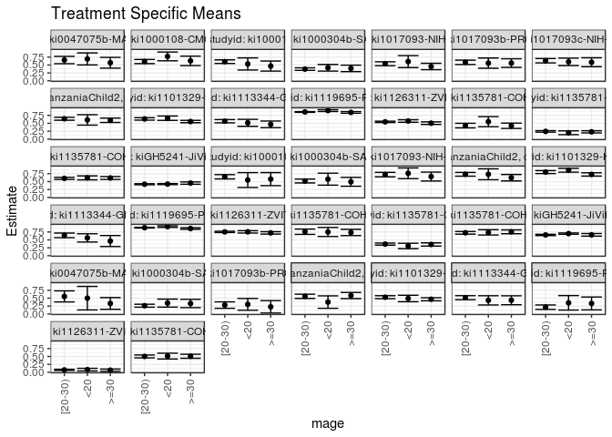

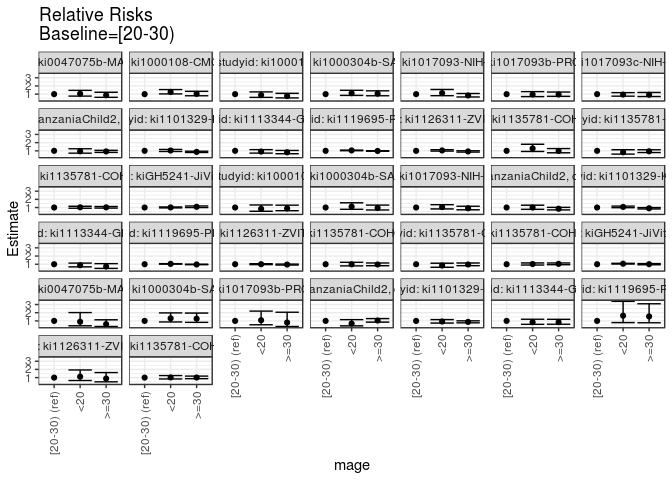

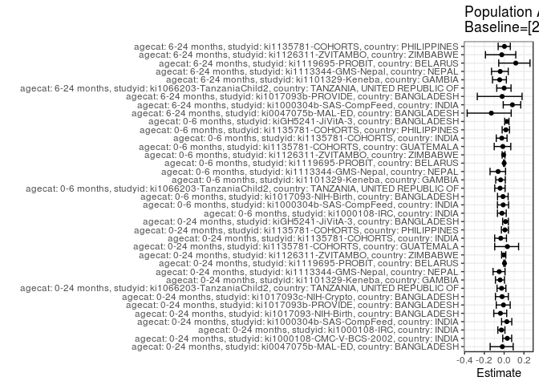

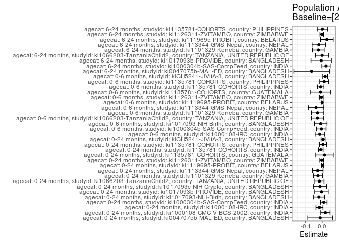

## Results Table

### Parameter: TSM

| agecat | studyid | country | intervention_level | baseline_level | estimate | ci_lower | ci_upper |
| --- | --- | --- | --- | --- | --- | --- | --- |
| 0-24 months | ki0047075b-MAL-ED | BANGLADESH | [20-30) | NA | 0.6571429 | 0.5406898 | 0.7735959 |
| 0-24 months | ki0047075b-MAL-ED | BANGLADESH | <20 | NA | 0.6923077 | 0.5029558 | 0.8816596 |
| 0-24 months | ki0047075b-MAL-ED | BANGLADESH | >=30 | NA | 0.5714286 | 0.4018241 | 0.7410330 |
| 0-24 months | ki1000108-CMC-V-BCS-2002 | INDIA | [20-30) | NA | 0.6095618 | 0.5440036 | 0.6751199 |
| 0-24 months | ki1000108-CMC-V-BCS-2002 | INDIA | <20 | NA | 0.7714286 | 0.6337889 | 0.9090682 |
| 0-24 months | ki1000108-CMC-V-BCS-2002 | INDIA | >=30 | NA | 0.6315789 | 0.4824082 | 0.7807497 |
| 0-24 months | ki1000108-IRC | INDIA | [20-30) | NA | 0.6059701 | 0.5489040 | 0.6630363 |
| 0-24 months | ki1000108-IRC | INDIA | <20 | NA | 0.5333333 | 0.3421602 | 0.7245064 |
| 0-24 months | ki1000108-IRC | INDIA | >=30 | NA | 0.4666667 | 0.3071858 | 0.6261475 |
| 0-24 months | ki1000304b-SAS-CompFeed | INDIA | [20-30) | NA | 0.3705717 | 0.3304981 | 0.4106453 |
| 0-24 months | ki1000304b-SAS-CompFeed | INDIA | <20 | NA | 0.4126033 | 0.3077178 | 0.5174888 |
| 0-24 months | ki1000304b-SAS-CompFeed | INDIA | >=30 | NA | 0.3932720 | 0.2912235 | 0.4953204 |
| 0-24 months | ki1017093-NIH-Birth | BANGLADESH | [20-30) | NA | 0.5398032 | 0.4782015 | 0.6014048 |
| 0-24 months | ki1017093-NIH-Birth | BANGLADESH | <20 | NA | 0.6086859 | 0.4195987 | 0.7977731 |
| 0-24 months | ki1017093-NIH-Birth | BANGLADESH | >=30 | NA | 0.4523606 | 0.3511624 | 0.5535588 |
| 0-24 months | ki1017093b-PROVIDE | BANGLADESH | [20-30) | NA | 0.5851378 | 0.5167736 | 0.6535020 |
| 0-24 months | ki1017093b-PROVIDE | BANGLADESH | <20 | NA | 0.5596390 | 0.3983156 | 0.7209623 |
| 0-24 months | ki1017093b-PROVIDE | BANGLADESH | >=30 | NA | 0.5611631 | 0.4250856 | 0.6972405 |
| 0-24 months | ki1017093c-NIH-Crypto | BANGLADESH | [20-30) | NA | 0.6354454 | 0.5661956 | 0.7046953 |
| 0-24 months | ki1017093c-NIH-Crypto | BANGLADESH | <20 | NA | 0.6006445 | 0.4830913 | 0.7181976 |
| 0-24 months | ki1017093c-NIH-Crypto | BANGLADESH | >=30 | NA | 0.5871392 | 0.4460366 | 0.7282417 |
| 0-24 months | ki1066203-TanzaniaChild2 | TANZANIA, UNITED REPUBLIC OF | [20-30) | NA | 0.6431704 | 0.5966814 | 0.6896595 |
| 0-24 months | ki1066203-TanzaniaChild2 | TANZANIA, UNITED REPUBLIC OF | <20 | NA | 0.6072416 | 0.4424651 | 0.7720181 |
| 0-24 months | ki1066203-TanzaniaChild2 | TANZANIA, UNITED REPUBLIC OF | >=30 | NA | 0.5956717 | 0.5263045 | 0.6650388 |
| 0-24 months | ki1101329-Keneba | GAMBIA | [20-30) | NA | 0.6377394 | 0.5997268 | 0.6757519 |
| 0-24 months | ki1101329-Keneba | GAMBIA | <20 | NA | 0.6608005 | 0.5917550 | 0.7298460 |
| 0-24 months | ki1101329-Keneba | GAMBIA | >=30 | NA | 0.5552358 | 0.5183136 | 0.5921581 |
| 0-24 months | ki1113344-GMS-Nepal | NEPAL | [20-30) | NA | 0.5665813 | 0.5156588 | 0.6175039 |
| 0-24 months | ki1113344-GMS-Nepal | NEPAL | <20 | NA | 0.5149221 | 0.4050188 | 0.6248254 |
| 0-24 months | ki1113344-GMS-Nepal | NEPAL | >=30 | NA | 0.4660218 | 0.3612618 | 0.5707818 |

[output cut: 81 more lines]

### Parameter: E(Y)

| agecat | studyid | country | intervention_level | baseline_level | estimate | ci_lower | ci_upper |
| --- | --- | --- | --- | --- | --- | --- | --- |
| 0-24 months | ki0047075b-MAL-ED | BANGLADESH | NA | NA | 0.6451613 | 0.5593015 | 0.7310211 |
| 0-24 months | ki1000108-CMC-V-BCS-2002 | INDIA | NA | NA | 0.6296296 | 0.5734927 | 0.6857666 |
| 0-24 months | ki1000108-IRC | INDIA | NA | NA | 0.5898734 | 0.5376978 | 0.6420491 |
| 0-24 months | ki1000304b-SAS-CompFeed | INDIA | NA | NA | 0.3808354 | 0.3457640 | 0.4159068 |
| 0-24 months | ki1017093-NIH-Birth | BANGLADESH | NA | NA | 0.5202864 | 0.4695109 | 0.5710618 |
| 0-24 months | ki1017093b-PROVIDE | BANGLADESH | NA | NA | 0.5811688 | 0.5245443 | 0.6377934 |
| 0-24 months | ki1017093c-NIH-Crypto | BANGLADESH | NA | NA | 0.6225806 | 0.5684562 | 0.6767051 |
| 0-24 months | ki1066203-TanzaniaChild2 | TANZANIA, UNITED REPUBLIC OF | NA | NA | 0.6267606 | 0.5890263 | 0.6644948 |
| 0-24 months | ki1101329-Keneba | GAMBIA | NA | NA | 0.6126374 | 0.5884768 | 0.6367979 |
| 0-24 months | ki1113344-GMS-Nepal | NEPAL | NA | NA | 0.5396579 | 0.4973524 | 0.5819633 |
| 0-24 months | ki1119695-PROBIT | BELARUS | NA | NA | 0.8612051 | 0.8511051 | 0.8713052 |
| 0-24 months | ki1126311-ZVITAMBO | ZIMBABWE | NA | NA | 0.5434360 | 0.5270156 | 0.5598565 |
| 0-24 months | ki1135781-COHORTS | GUATEMALA | NA | NA | 0.4421053 | 0.3904403 | 0.4937702 |
| 0-24 months | ki1135781-COHORTS | INDIA | NA | NA | 0.2355670 | 0.2165976 | 0.2545364 |
| 0-24 months | ki1135781-COHORTS | PHILIPPINES | NA | NA | 0.6068680 | 0.5823645 | 0.6313715 |
| 0-24 months | kiGH5241-JiVitA-3 | BANGLADESH | NA | NA | 0.4221929 | 0.4110723 | 0.4333134 |
| 0-6 months | ki1000108-IRC | INDIA | NA | NA | 0.6375000 | 0.5751450 | 0.6998550 |
| 0-6 months | ki1000304b-SAS-CompFeed | INDIA | NA | NA | 0.5131965 | 0.4596632 | 0.5667297 |
| 0-6 months | ki1017093-NIH-Birth | BANGLADESH | NA | NA | 0.7130045 | 0.6535890 | 0.7724200 |
| 0-6 months | ki1066203-TanzaniaChild2 | TANZANIA, UNITED REPUBLIC OF | NA | NA | 0.7020649 | 0.6526590 | 0.7514708 |
| 0-6 months | ki1101329-Keneba | GAMBIA | NA | NA | 0.7728532 | 0.7426787 | 0.8030276 |
| 0-6 months | ki1113344-GMS-Nepal | NEPAL | NA | NA | 0.6045627 | 0.5449300 | 0.6641955 |
| 0-6 months | ki1119695-PROBIT | BELARUS | NA | NA | 0.8855266 | 0.8758983 | 0.8951550 |
| 0-6 months | ki1126311-ZVITAMBO | ZIMBABWE | NA | NA | 0.7485054 | 0.7315407 | 0.7654701 |
| 0-6 months | ki1135781-COHORTS | GUATEMALA | NA | NA | 0.7476636 | 0.6894668 | 0.8058603 |
| 0-6 months | ki1135781-COHORTS | INDIA | NA | NA | 0.3581505 | 0.3318331 | 0.3844678 |
| 0-6 months | ki1135781-COHORTS | PHILIPPINES | NA | NA | 0.7367021 | 0.7051294 | 0.7682749 |
| 0-6 months | kiGH5241-JiVitA-3 | BANGLADESH | NA | NA | 0.6752588 | 0.6619177 | 0.6885999 |
| 6-24 months | ki0047075b-MAL-ED | BANGLADESH | NA | NA | 0.4918033 | 0.3610932 | 0.6225134 |
| 6-24 months | ki1000304b-SAS-CompFeed | INDIA | NA | NA | 0.2854123 | 0.2436284 | 0.3271961 |
| 6-24 months | ki1017093b-PROVIDE | BANGLADESH | NA | NA | 0.2764228 | 0.1950773 | 0.3577682 |
| 6-24 months | ki1066203-TanzaniaChild2 | TANZANIA, UNITED REPUBLIC OF | NA | NA | 0.5579515 | 0.5056058 | 0.6102972 |
| 6-24 months | ki1101329-Keneba | GAMBIA | NA | NA | 0.5072860 | 0.4757518 | 0.5388202 |
| 6-24 months | ki1113344-GMS-Nepal | NEPAL | NA | NA | 0.4947368 | 0.4401559 | 0.5493178 |
| 6-24 months | ki1119695-PROBIT | BELARUS | NA | NA | 0.2440476 | 0.1791134 | 0.3089818 |
| 6-24 months | ki1126311-ZVITAMBO | ZIMBABWE | NA | NA | 0.0731261 | 0.0577817 | 0.0884705 |
| 6-24 months | ki1135781-COHORTS | PHILIPPINES | NA | NA | 0.5026681 | 0.4688378 | 0.5364984 |

### Parameter: RR

| agecat | studyid | country | intervention_level | baseline_level | estimate | ci_lower | ci_upper |
| --- | --- | --- | --- | --- | --- | --- | --- |
| 0-24 months | ki0047075b-MAL-ED | BANGLADESH | [20-30) | [20-30) | 1.0000000 | 1.0000000 | 1.0000000 |
| 0-24 months | ki0047075b-MAL-ED | BANGLADESH | <20 | [20-30) | 1.0535117 | 0.7605022 | 1.4594131 |
| 0-24 months | ki0047075b-MAL-ED | BANGLADESH | >=30 | [20-30) | 0.8695652 | 0.6151686 | 1.2291649 |
| 0-24 months | ki1000108-CMC-V-BCS-2002 | INDIA | [20-30) | [20-30) | 1.0000000 | 1.0000000 | 1.0000000 |
| 0-24 months | ki1000108-CMC-V-BCS-2002 | INDIA | <20 | [20-30) | 1.2655462 | 1.0275196 | 1.5587122 |
| 0-24 months | ki1000108-CMC-V-BCS-2002 | INDIA | >=30 | [20-30) | 1.0361197 | 0.7992780 | 1.3431423 |
| 0-24 months | ki1000108-IRC | INDIA | [20-30) | [20-30) | 1.0000000 | 1.0000000 | 1.0000000 |
| 0-24 months | ki1000108-IRC | INDIA | <20 | [20-30) | 0.8801314 | 0.6075574 | 1.2749927 |
| 0-24 months | ki1000108-IRC | INDIA | >=30 | [20-30) | 0.7701149 | 0.5402651 | 1.0977519 |
| 0-24 months | ki1000304b-SAS-CompFeed | INDIA | [20-30) | [20-30) | 1.0000000 | 1.0000000 | 1.0000000 |
| 0-24 months | ki1000304b-SAS-CompFeed | INDIA | <20 | [20-30) | 1.1134236 | 0.8449725 | 1.4671627 |
| 0-24 months | ki1000304b-SAS-CompFeed | INDIA | >=30 | [20-30) | 1.0612573 | 0.8013527 | 1.4054574 |
| 0-24 months | ki1017093-NIH-Birth | BANGLADESH | [20-30) | [20-30) | 1.0000000 | 1.0000000 | 1.0000000 |
| 0-24 months | ki1017093-NIH-Birth | BANGLADESH | <20 | [20-30) | 1.1276071 | 0.8101713 | 1.5694185 |
| 0-24 months | ki1017093-NIH-Birth | BANGLADESH | >=30 | [20-30) | 0.8380103 | 0.6525311 | 1.0762111 |
| 0-24 months | ki1017093b-PROVIDE | BANGLADESH | [20-30) | [20-30) | 1.0000000 | 1.0000000 | 1.0000000 |
| 0-24 months | ki1017093b-PROVIDE | BANGLADESH | <20 | [20-30) | 0.9564226 | 0.7004870 | 1.3058687 |
| 0-24 months | ki1017093b-PROVIDE | BANGLADESH | >=30 | [20-30) | 0.9590272 | 0.7326448 | 1.2553603 |
| 0-24 months | ki1017093c-NIH-Crypto | BANGLADESH | [20-30) | [20-30) | 1.0000000 | 1.0000000 | 1.0000000 |
| 0-24 months | ki1017093c-NIH-Crypto | BANGLADESH | <20 | [20-30) | 0.9452337 | 0.7553881 | 1.1827917 |
| 0-24 months | ki1017093c-NIH-Crypto | BANGLADESH | >=30 | [20-30) | 0.9239805 | 0.7091911 | 1.2038222 |
| 0-24 months | ki1066203-TanzaniaChild2 | TANZANIA, UNITED REPUBLIC OF | [20-30) | [20-30) | 1.0000000 | 1.0000000 | 1.0000000 |
| 0-24 months | ki1066203-TanzaniaChild2 | TANZANIA, UNITED REPUBLIC OF | <20 | [20-30) | 0.9441379 | 0.7128099 | 1.2505388 |
| 0-24 months | ki1066203-TanzaniaChild2 | TANZANIA, UNITED REPUBLIC OF | >=30 | [20-30) | 0.9261490 | 0.8076320 | 1.0620580 |
| 0-24 months | ki1101329-Keneba | GAMBIA | [20-30) | [20-30) | 1.0000000 | 1.0000000 | 1.0000000 |
| 0-24 months | ki1101329-Keneba | GAMBIA | <20 | [20-30) | 1.0361608 | 0.9188859 | 1.1684031 |
| 0-24 months | ki1101329-Keneba | GAMBIA | >=30 | [20-30) | 0.8706312 | 0.7964445 | 0.9517283 |
| 0-24 months | ki1113344-GMS-Nepal | NEPAL | [20-30) | [20-30) | 1.0000000 | 1.0000000 | 1.0000000 |
| 0-24 months | ki1113344-GMS-Nepal | NEPAL | <20 | [20-30) | 0.9088229 | 0.7207126 | 1.1460312 |
| 0-24 months | ki1113344-GMS-Nepal | NEPAL | >=30 | [20-30) | 0.8225153 | 0.6455896 | 1.0479281 |

[output cut: 81 more lines]

### Parameter: PAR

| agecat | studyid | country | intervention_level | baseline_level | estimate | ci_lower | ci_upper |
| --- | --- | --- | --- | --- | --- | --- | --- |
| 0-24 months | ki0047075b-MAL-ED | BANGLADESH | [20-30) | NA | -0.0119816 | -0.0869654 | 0.0630023 |
| 0-24 months | ki1000108-CMC-V-BCS-2002 | INDIA | [20-30) | NA | 0.0200679 | -0.0081753 | 0.0483111 |
| 0-24 months | ki1000108-IRC | INDIA | [20-30) | NA | -0.0160967 | -0.0373720 | 0.0051786 |
| 0-24 months | ki1000304b-SAS-CompFeed | INDIA | [20-30) | NA | 0.0102636 | -0.0093441 | 0.0298714 |
| 0-24 months | ki1017093-NIH-Birth | BANGLADESH | [20-30) | NA | -0.0195168 | -0.0535090 | 0.0144754 |
| 0-24 months | ki1017093b-PROVIDE | BANGLADESH | [20-30) | NA | -0.0039690 | -0.0448889 | 0.0369510 |
| 0-24 months | ki1017093c-NIH-Crypto | BANGLADESH | [20-30) | NA | -0.0128648 | -0.0534291 | 0.0276996 |
| 0-24 months | ki1066203-TanzaniaChild2 | TANZANIA, UNITED REPUBLIC OF | [20-30) | NA | -0.0164099 | -0.0443945 | 0.0115748 |
| 0-24 months | ki1101329-Keneba | GAMBIA | [20-30) | NA | -0.0251020 | -0.0531410 | 0.0029370 |
| 0-24 months | ki1113344-GMS-Nepal | NEPAL | [20-30) | NA | -0.0269235 | -0.0594794 | 0.0056324 |
| 0-24 months | ki1119695-PROBIT | BELARUS | [20-30) | NA | 0.0030915 | -0.0031283 | 0.0093114 |
| 0-24 months | ki1126311-ZVITAMBO | ZIMBABWE | [20-30) | NA | -0.0023288 | -0.0139081 | 0.0092504 |
| 0-24 months | ki1135781-COHORTS | GUATEMALA | [20-30) | NA | 0.0144870 | -0.0387908 | 0.0677647 |
| 0-24 months | ki1135781-COHORTS | INDIA | [20-30) | NA | -0.0081072 | -0.0221855 | 0.0059711 |
| 0-24 months | ki1135781-COHORTS | PHILIPPINES | [20-30) | NA | 0.0050528 | -0.0165177 | 0.0266233 |
| 0-24 months | kiGH5241-JiVitA-3 | BANGLADESH | [20-30) | NA | 0.0059415 | -0.0063009 | 0.0181840 |
| 0-6 months | ki1000108-IRC | INDIA | [20-30) | NA | -0.0142413 | -0.0424320 | 0.0139495 |
| 0-6 months | ki1000304b-SAS-CompFeed | INDIA | [20-30) | NA | -0.0050450 | -0.0340051 | 0.0239152 |
| 0-6 months | ki1017093-NIH-Birth | BANGLADESH | [20-30) | NA | -0.0085145 | -0.0467921 | 0.0297631 |
| 0-6 months | ki1066203-TanzaniaChild2 | TANZANIA, UNITED REPUBLIC OF | [20-30) | NA | -0.0288768 | -0.0655418 | 0.0077881 |
| 0-6 months | ki1101329-Keneba | GAMBIA | [20-30) | NA | -0.0274154 | -0.0649337 | 0.0101029 |
| 0-6 months | ki1113344-GMS-Nepal | NEPAL | [20-30) | NA | -0.0370332 | -0.0841173 | 0.0100510 |
| 0-6 months | ki1119695-PROBIT | BELARUS | [20-30) | NA | 0.0000856 | -0.0059020 | 0.0060732 |
| 0-6 months | ki1126311-ZVITAMBO | ZIMBABWE | [20-30) | NA | -0.0041580 | -0.0149456 | 0.0066296 |
| 0-6 months | ki1135781-COHORTS | GUATEMALA | [20-30) | NA | -0.0099122 | -0.0724377 | 0.0526132 |
| 0-6 months | ki1135781-COHORTS | INDIA | [20-30) | NA | -0.0085667 | -0.0280522 | 0.0109188 |
| 0-6 months | ki1135781-COHORTS | PHILIPPINES | [20-30) | NA | 0.0129369 | -0.0143524 | 0.0402261 |
| 0-6 months | kiGH5241-JiVitA-3 | BANGLADESH | [20-30) | NA | 0.0187181 | 0.0042236 | 0.0332125 |
| 6-24 months | ki0047075b-MAL-ED | BANGLADESH | [20-30) | NA | -0.0637523 | -0.1721469 | 0.0446423 |
| 6-24 months | ki1000304b-SAS-CompFeed | INDIA | [20-30) | NA | 0.0237701 | -0.0015583 | 0.0490984 |
| 6-24 months | ki1017093b-PROVIDE | BANGLADESH | [20-30) | NA | -0.0056285 | -0.0676577 | 0.0564006 |
| 6-24 months | ki1066203-TanzaniaChild2 | TANZANIA, UNITED REPUBLIC OF | [20-30) | NA | -0.0000220 | -0.0402855 | 0.0402416 |
| 6-24 months | ki1101329-Keneba | GAMBIA | [20-30) | NA | -0.0230145 | -0.0585684 | 0.0125393 |
| 6-24 months | ki1113344-GMS-Nepal | NEPAL | [20-30) | NA | -0.0196696 | -0.0611059 | 0.0217667 |
| 6-24 months | ki1119695-PROBIT | BELARUS | [20-30) | NA | 0.0286630 | -0.0101059 | 0.0674319 |
| 6-24 months | ki1126311-ZVITAMBO | ZIMBABWE | [20-30) | NA | -0.0017792 | -0.0129271 | 0.0093688 |
| 6-24 months | ki1135781-COHORTS | PHILIPPINES | [20-30) | NA | 0.0013869 | -0.0294567 | 0.0322305 |

### Parameter: PAF

| agecat | studyid | country | intervention_level | baseline_level | estimate | ci_lower | ci_upper |
| --- | --- | --- | --- | --- | --- | --- | --- |
| 0-24 months | ki0047075b-MAL-ED | BANGLADESH | [20-30) | NA | -0.0185714 | -0.1415944 | 0.0911941 |
| 0-24 months | ki1000108-CMC-V-BCS-2002 | INDIA | [20-30) | NA | 0.0318725 | -0.0144597 | 0.0760887 |
| 0-24 months | ki1000108-IRC | INDIA | [20-30) | NA | -0.0272885 | -0.0639884 | 0.0081456 |
| 0-24 months | ki1000304b-SAS-CompFeed | INDIA | [20-30) | NA | 0.0269504 | -0.0259689 | 0.0771401 |
| 0-24 months | ki1017093-NIH-Birth | BANGLADESH | [20-30) | NA | -0.0375116 | -0.1049863 | 0.0258429 |
| 0-24 months | ki1017093b-PROVIDE | BANGLADESH | [20-30) | NA | -0.0068293 | -0.0797946 | 0.0612056 |
| 0-24 months | ki1017093c-NIH-Crypto | BANGLADESH | [20-30) | NA | -0.0206637 | -0.0878736 | 0.0423940 |
| 0-24 months | ki1066203-TanzaniaChild2 | TANZANIA, UNITED REPUBLIC OF | [20-30) | NA | -0.0261820 | -0.0718820 | 0.0175695 |
| 0-24 months | ki1101329-Keneba | GAMBIA | [20-30) | NA | -0.0409737 | -0.0876987 | 0.0037442 |
| 0-24 months | ki1113344-GMS-Nepal | NEPAL | [20-30) | NA | -0.0498899 | -0.1125017 | 0.0091982 |
| 0-24 months | ki1119695-PROBIT | BELARUS | [20-30) | NA | 0.0035898 | -0.0036602 | 0.0107874 |
| 0-24 months | ki1126311-ZVITAMBO | ZIMBABWE | [20-30) | NA | -0.0042854 | -0.0258206 | 0.0167978 |
| 0-24 months | ki1135781-COHORTS | GUATEMALA | [20-30) | NA | 0.0327681 | -0.0954610 | 0.1459873 |
| 0-24 months | ki1135781-COHORTS | INDIA | [20-30) | NA | -0.0344155 | -0.0958009 | 0.0235312 |
| 0-24 months | ki1135781-COHORTS | PHILIPPINES | [20-30) | NA | 0.0083260 | -0.0278865 | 0.0432628 |
| 0-24 months | kiGH5241-JiVitA-3 | BANGLADESH | [20-30) | NA | 0.0140730 | -0.0153578 | 0.0426508 |
| 0-6 months | ki1000108-IRC | INDIA | [20-30) | NA | -0.0223393 | -0.0676463 | 0.0210451 |
| 0-6 months | ki1000304b-SAS-CompFeed | INDIA | [20-30) | NA | -0.0098305 | -0.0678830 | 0.0450662 |
| 0-6 months | ki1017093-NIH-Birth | BANGLADESH | [20-30) | NA | -0.0119417 | -0.0670961 | 0.0403619 |
| 0-6 months | ki1066203-TanzaniaChild2 | TANZANIA, UNITED REPUBLIC OF | [20-30) | NA | -0.0411313 | -0.0950270 | 0.0101118 |
| 0-6 months | ki1101329-Keneba | GAMBIA | [20-30) | NA | -0.0354730 | -0.0852813 | 0.0120494 |
| 0-6 months | ki1113344-GMS-Nepal | NEPAL | [20-30) | NA | -0.0612561 | -0.1427310 | 0.0144098 |
| 0-6 months | ki1119695-PROBIT | BELARUS | [20-30) | NA | 0.0000967 | -0.0066879 | 0.0068355 |
| 0-6 months | ki1126311-ZVITAMBO | ZIMBABWE | [20-30) | NA | -0.0055551 | -0.0200711 | 0.0087544 |
| 0-6 months | ki1135781-COHORTS | GUATEMALA | [20-30) | NA | -0.0132576 | -0.1004856 | 0.0670564 |
| 0-6 months | ki1135781-COHORTS | INDIA | [20-30) | NA | -0.0239193 | -0.0797959 | 0.0290659 |
| 0-6 months | ki1135781-COHORTS | PHILIPPINES | [20-30) | NA | 0.0175605 | -0.0202376 | 0.0539583 |
| 0-6 months | kiGH5241-JiVitA-3 | BANGLADESH | [20-30) | NA | 0.0277198 | 0.0059939 | 0.0489709 |
| 6-24 months | ki0047075b-MAL-ED | BANGLADESH | [20-30) | NA | -0.1296296 | -0.3739720 | 0.0712597 |
| 6-24 months | ki1000304b-SAS-CompFeed | INDIA | [20-30) | NA | 0.0832833 | -0.0096216 | 0.1676391 |
| 6-24 months | ki1017093b-PROVIDE | BANGLADESH | [20-30) | NA | -0.0203620 | -0.2715476 | 0.1812036 |
| 6-24 months | ki1066203-TanzaniaChild2 | TANZANIA, UNITED REPUBLIC OF | [20-30) | NA | -0.0000393 | -0.0748700 | 0.0695817 |
| 6-24 months | ki1101329-Keneba | GAMBIA | [20-30) | NA | -0.0453680 | -0.1178680 | 0.0224300 |
| 6-24 months | ki1113344-GMS-Nepal | NEPAL | [20-30) | NA | -0.0397577 | -0.1276439 | 0.0412788 |
| 6-24 months | ki1119695-PROBIT | BELARUS | [20-30) | NA | 0.1174484 | -0.0545543 | 0.2613967 |
| 6-24 months | ki1126311-ZVITAMBO | ZIMBABWE | [20-30) | NA | -0.0243301 | -0.1890234 | 0.1175513 |
| 6-24 months | ki1135781-COHORTS | PHILIPPINES | [20-30) | NA | 0.0027591 | -0.0605299 | 0.0622712 |